# What does climate change mean for Eastern Texas?

Mireya Valencia

2/20/2017

#### Is Texas warming or cooling, and how do we know?

Texas’s large coast and overreliance on its abundant natural resources render it particularly vulnerable to climate change. The Environmental Protection Agency estimates that the state has warmed 0.5-1°F in the past century (“What Climate Change Means for Texas”). Although this number may seem underwhelming, even a minimal increase in temperature can exacerbate issues such as rising sea levels, extreme weather events, drought, and floods.

Alvin, a small city in the Houston metropolitan area of Texas, is home to a weather station that has collected local weather data since 1898, longer than any other weather station in Eastern Texas.

[figure not shown]

The data, available online through the National Oceanic and Atmospheric Administration (NOAA), is helpful in analyzing local weather and climate trends in nearby Houston and Galveston. To determine whether temperature has increased in Texas over the past century, we will analyze the NOAA data and perform a series of statistical tests to determine the data’s validity.

Let us begin by creating hypotheses. In accordance with the scientific method, the null hypothesis predicts that there is no observed relationship between variables. In our case, this would mean that Texas is not warming. Generally, a rejection of the null hypothesis means there is evidence to support the alternative hypothesis.

Alternative Hypothesis: The maximum temperature in Alvin, TX from 1898-2013 has increased.

Null Hypothesis: The maximum temperature in Alvin, TX from 1898-2013 has not increased from 1898-2013.

To test the null hypothesis we will input the data into R, an open source statistical computing software. The program will calcuate a p-value, or the probablity of an event happening by chance. A p-value of <0.05 leads to a rejection of the null hypothesis.

#### An increasing trend in temperatures

Below are the maximum mean temperatures in Alvin, TX from 1898-2013. There is an overall increasing trend in the data. However, with a non-significant p-value of 0.30, we cannot reject the null hypothesis. In other words, although there’s an increasing trend in temperatures, we cannot know for sure if it was due to chance.

Note: the red line represents the slope of the data.

[figure not shown]

#### Are the results valid?

As shown in the previous graph, there is a huge portion of missing data from about 1920-1960. A gap in data this large poses questions about the validity of the results. To see if the trend exists independently of this missing data, we can look only at the data collected after 1960.

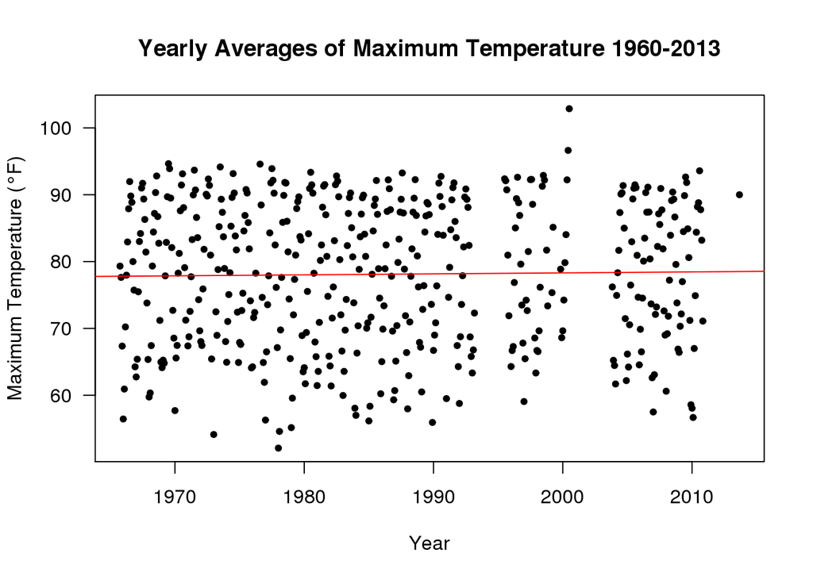

#### Looking closer: a month by month analysis

To analyze statistically significant data, we can look at montlhy maximum temperatures.

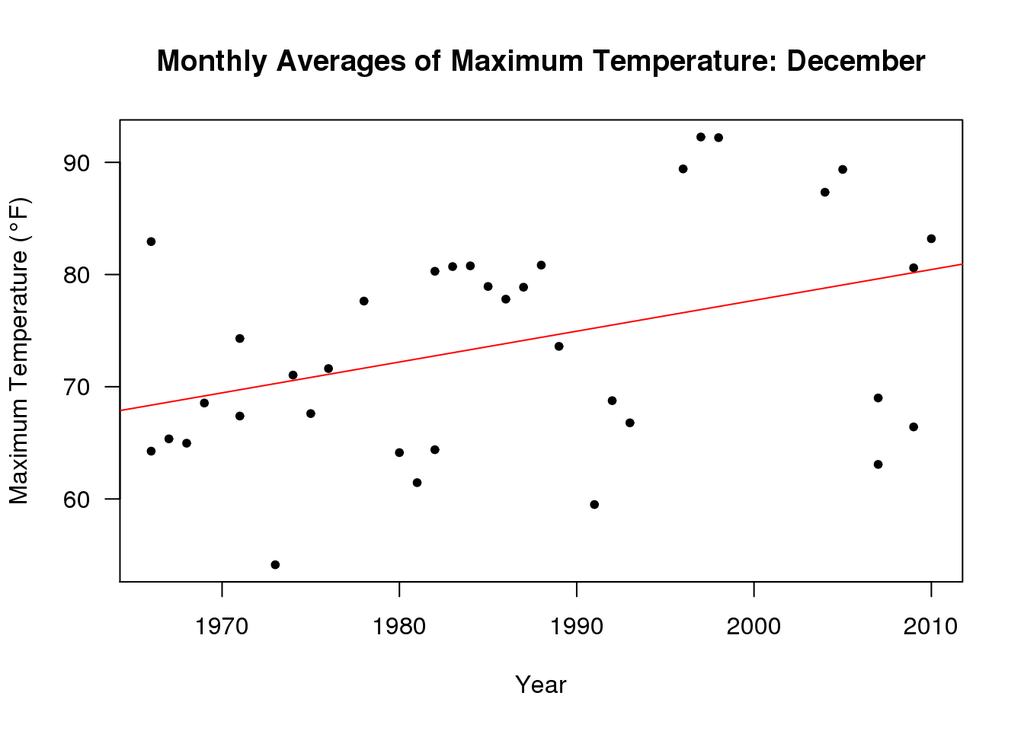

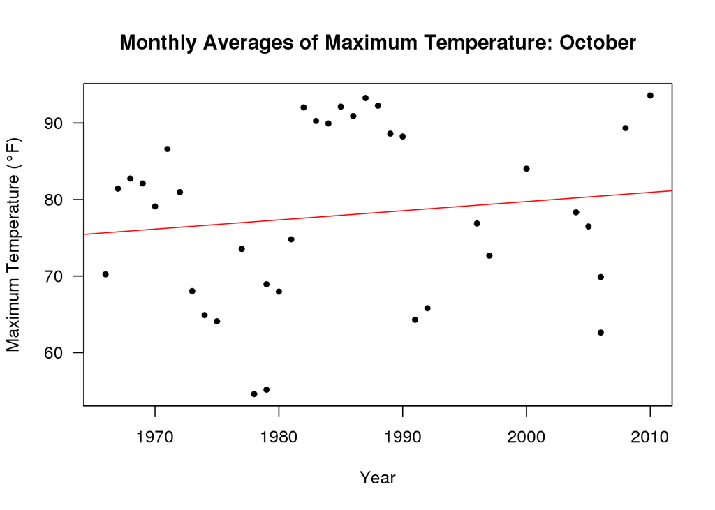

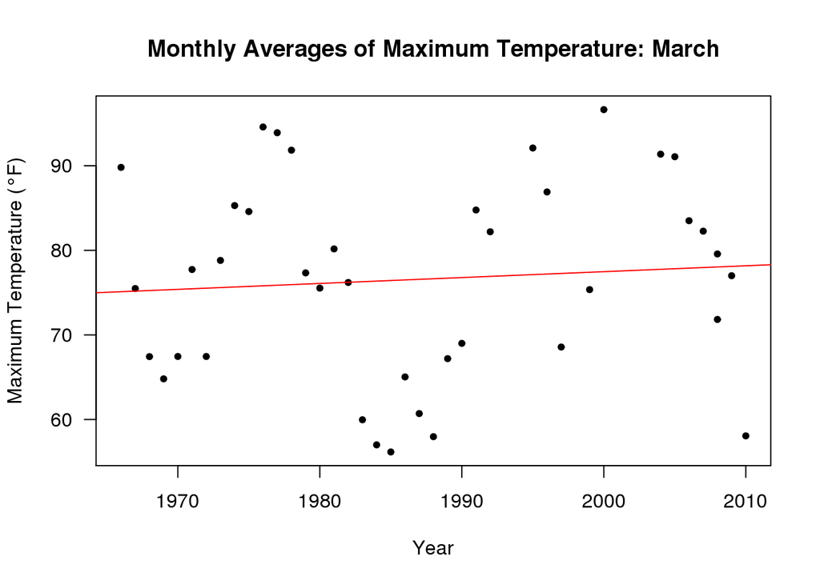

## What does all this mean for you?

#### A vulnerable economy

Rising temperatures not only threaten human health, but they also endanger Texas’s economy. In 2014, cotton, corn, and hay crops accounted for $4.4 billion in production for Texas. Crops are largely susceptible to changes in heat and precipitation, and it is estimated that corn yields will drop 22% by 2040. Cattle and calves generated $10.5 billion in 2012, but extreme heat can affect performance, production, production, and fertility of the animals. Extreme droughts in the area have already caused small farmers in the region to relocate or sell their herds (“Come Heat and High Water”). Not only will Texas’s economy be hit hard by a loss in agricultural revenue, but the Texan consumer could be subjected to higher prices in the supermarket due to a decrease in supply.

#### Flooding and property damage

As temperatures increase, the EPA estimates that Texas’s sea levels will rise anywhere from two to five feet within the next century (“What Climate Change Means for Texas”). Texas’s rising sea levels are exacerbated by local groundwater and oil pumping, which cause land to sink. Texas produces one-fifth of the country’s oil and nearly one-third of its natural gas, making the oil industry a huge part of Texas’s economy (“Come Heat and High Water”). Data has shown that increased oil drilling and groundwater pumping are causing Texas to surpass its historical subsidence rates (Paine). In practical terms, rising sea levels and sinking land means flooding: billions of dollars’ worth of flooding. Texas has more miles of highway and railroads than any other state, and there is a large trading hub in the port of Houston (“Come Heat and High Water”). Flooding would not only endanger this infrastructure, but it would also pose a threat to coastal property. A recent study cross-examined maps released by the National Oceanic Atmospheric Administration with house values in coastal areas across the United States. The study reveals that 40% of homes in Galveston will be flooded by 2100, totaling a loss of $2.9 billion. Houston will lose around 30 homes, or $4 million. (“Climate Change and Housing”).

#### Literature Cited

“Climate Change and Housing: Will a Rising Tide Sink All Homes?” Zillow Research. N.p., 2 Aug. 2016. Web. 25 Jan. 2017. “Come Heat and High Water: Climate Risk in the Southeastern U.S. and Texas — Risky Business.” Risky Business. N.p., n.d. Web. 17 Mar. 2017. Paine, Jeffrey G. “Subsidence of the Texas Coast: Inferences from Historical and Late Pleistocene Sea Levels.” Tectonophysics 222.3 (1993): 445–458. ScienceDirect. Web. Geological Perspetives on Global Change. “What Climate Change Means for Texas.” United States Environmental Protection Agency EPA 430-F-16-045 (2016): n. pag. Print.